# R Notebook

## Important links

- https://www.soupersage.com/blog/30-most-popular-recipe-ingredients-2019/
- https://flowingdata.com/2018/09/18/cuisine-ingredients/
- https://www.kaggle.com/shuyangli94/food-com-recipes-and-user-interactions?select=ingr_map.pkl - ingredient data (can be sorted by frequency)

```r
library(stringr)
```

The ingredients map was originally downloaded in the .pkl format and converted to csv in python. Now, it can be loaded into the R notebook

```r
ingr_filepath <- '/Users/sofyamalashchenko/Documents/Sofya/Uni\ stuff/Waterloo\ Winter\ 2022/Ingredient-detection/ingr_map.csv'
ingr <- read.csv(ingr_filepath)
ingr
```

| X | raw_ingr | raw_words | processed | len_proc | replaced | count | id |
| --- | --- | --- | --- | --- | --- | --- | --- |
| 0 | medium heads bibb or red leaf lettuce, washed, dried* and torn into pieces | 13 | medium heads bibb or red leaf lettuce, washed, dried* and torn into piece | 73 | lettuce | 4507 | 4308 |
| 1 | mixed baby lettuces and spring greens | 6 | mixed baby lettuces and spring green | 36 | lettuce | 4507 | 4308 |
| 2 | romaine lettuce leaf | 3 | romaine lettuce leaf | 20 | lettuce | 4507 | 4308 |
| 3 | iceberg lettuce leaf | 3 | iceberg lettuce leaf | 20 | lettuce | 4507 | 4308 |
| 4 | red romaine lettuce | 3 | red romaine lettuce | 19 | lettuce | 4507 | 4308 |
| 5 | head romaine lettuce | 3 | head romaine lettuce | 20 | lettuce | 4507 | 4308 |
| 6 | curly endive lettuce | 3 | curly endive lettuce | 20 | lettuce | 4507 | 4308 |
| 7 | romaine lettuce hearts | 3 | romaine lettuce heart | 21 | lettuce | 4507 | 4308 |
| 8 | baby leaf lettuce | 3 | baby leaf lettuce | 17 | lettuce | 4507 | 4308 |
| 9 | head of lettuce | 3 | head of lettuce | 15 | lettuce | 4507 | 4308 |

[output cut: 990 more lines]

The plan is to look at most used ingredients and use those as the starting point for the data collection process.

All available ingredients:

```r
unique(ingr["replaced"])
```

|  | replaced |
| --- | --- |
| 1 | lettuce |
| 43 | french vanilla pudding and pie filling mix |
| 44 | stove top stuffing mix |
| 46 | cream cheese |
| 87 | cheddar |
| 171 | radicchio |
| 173 | pasta sauce |
| 184 | tomato sauce |
| 202 | shredded three cheese |
| 203 | mozzarella |

[output cut: 990 more lines]

From here we can easily get the top most used ingredients however I would like to perform further research on the available recipes.

First, loading the recipe data from the same notebook and adding a column “NumIngredients” containing the number of ingredients required for each recipe.

```r
recipes_filepath <- '/Users/sofyamalashchenko/Documents/Sofya/Uni\ stuff/Waterloo\ Winter\ 2022/Ingredient-detection/PP_recipes.csv'
recipes <- read.csv(recipes_filepath)
```

First, convert the ingredient_ids column into a list format

```r
recipes$SepIngredients <- apply(recipes, 1,
                                FUN = function(x) as.numeric(scan(text=substr(x["ingredient_ids"],
                                                                   2,
                                                                   nchar(x["ingredient_ids"])-1),
                                                       what='',
                                                       sep = ',',
                                                       strip.white = TRUE,
                                                       quiet = TRUE)))
# Then count the number of ingredients in each and add it to a new column
recipes$NumIngredients <- apply(recipes, 1, FUN = function(x) length(x$SepIngredients))
recipes
```

| id | i | name_tokens | ingredient_tokens | steps_tokens | techniques | calorie_level | ingredient_ids | SepIngredients | NumIngredients |
| --- | --- | --- | --- | --- | --- | --- | --- | --- | --- |
| 424415 | 23 | [40480, 37229, 2911, 1019, 249, 6878, 6878, 2839, 1781, 40481] | [[2911, 1019, 249, 6878], [1353], [6953], [15341, 3261], [2056, 857, 643, 1631, 20480]] | [40480, 40482, 21662, 481, 6878, 500, 246, 1614, 1911, 10757, 240, 674, 9933, 8400, 40478, 40482, 1082, 589, 16126, 500, 481, 6878, 2839, 1781, 5024, 240, 488, 13770, 485, 23667, 40478, 40482, 1233, 4… | [0, 0, 0, 0, 0, 0, 0, 0, 0, 1, 0, 0, 0, 0, 0, 0, 1, 0, 0, 0, 0, 0, 0, 0, 0, 0, 0, 0, 0, 0, 0, 0, 0, 0, 0, 0, 0, 0, 0, 0, 0, 0, 0, 0, 0, 0, 0, 0, 0, 0, 0, 1, 0, 0, 0, 0, 0, 0] | 0 | [389, 7655, 6270, 1527, 3406] |  | 5 |
| 146223 | 96900 | [40480, 18376, 7056, 246, 1531, 2032, 40481] | [[17918], [25916], [2507, 6444], [8467, 1179], [8780], [6812], [4370, 2653, 18376], [2654, 5581, 34904, 5940], [15341], [10848], [21447, 7869], [6953]] | [40480, 40482, 729, 2525, 10906, 485, 43, 8393, 40478, 40482, 23667, 17918, 240, 25916, 240, 2507, 6444, 488, 8467, 1179, 40478, 40482, 4846, 6737, 8780, 488, 7087, 862, 40478, 40482, 3336, 666, 481, … | [1, 0, 0, 0, 0, 0, 0, 0, 0, 1, 0, 0, 0, 0, 0, 0, 0, 0, 0, 0, 0, 0, 0, 0, 0, 0, 0, 0, 1, 0, 0, 0, 0, 1, 0, 0, 1, 0, 0, 0, 0, 0, 0, 0, 0, 0, 1, 0, 0, 0, 0, 0, 0, 0, 0, 0, 1, 1] | 0 | [2683, 4969, 800, 5298, 840, 2499, 6632, 7022, 1511, 3248, 4964, 6270] |  | 12 |
| 312329 | 120056 | [40480, 21044, 16954, 8294, 556, 10837, 40481] | [[5867, 24176], [1353], [6953], [1301, 11332], [21453, 8361], [25845, 8111, 11332], [23488, 8361], [37754, 10734], [652, 25, 3035, 11959, 10734], [10837], [19811, 21137, 556, 20323, 15022, 296, 7, 434… | [40480, 40482, 8240, 481, 24176, 296, 1353, 666, 246, 1719, 5082, 40478, 40482, 4846, 481, 21298, 240, 37754, 10734, 240, 652, 25, 3035, 11959, 240, 296, 10837, 485, 481, 5082, 674, 2030, 485, 246, 14… | [0, 0, 0, 0, 1, 0, 0, 0, 0, 0, 0, 1, 0, 0, 0, 0, 0, 0, 0, 0, 0, 0, 0, 0, 0, 0, 0, 0, 1, 0, 0, 0, 0, 1, 0, 0, 0, 0, 0, 0, 0, 0, 1, 0, 0, 0, 0, 0, 0, 0, 0, 0, 0, 0, 0, 0, 0, 0] | 1 | [1257, 7655, 6270, 590, 5024, 1119, 4883, 6696, 7946, 5648, 7239, 7705, 7594, 1168, 2683] |  | 15 |
| 74301 | 168258 | [40480, 10025, 31156, 40481] | [[1270, 1645, 28447], [21601], [27952, 29471, 484], [31843], [6821], [9514, 4914], [10444], [692, 37297, 17128]] | [40480, 40482, 5539, 21601, 1073, 903, 2324, 40478, 40482, 9933, 481, 4739, 488, 9467, 500, 27952, 7087, 488, 277, 278, 280, 3026, 31843, 278, 1251, 14923, 10734, 40478, 40482, 32093, 562, 281, 260, 2… | [1, 0, 0, 0, 0, 0, 0, 0, 0, 0, 0, 0, 0, 0, 0, 0, 1, 0, 0, 0, 0, 0, 0, 0, 0, 0, 0, 0, 0, 0, 0, 0, 0, 0, 0, 0, 0, 0, 0, 0, 0, 0, 1, 0, 0, 0, 0, 0, 0, 0, 0, 0, 0, 0, 0, 0, 0, 0] | 0 | [7940, 3609, 7060, 6265, 1170, 6654, 5003, 3561] |  | 8 |
| 76272 | 109030 | [40480, 17841, 252, 782, 2373, 1641, 2373, 252, 40481] | [[1430, 11434], [1430, 17027], [1615, 23, 695, 2338, 6821], [13134, 2555, 29273, 9410]] | [40480, 40482, 14046, 1430, 11434, 488, 17027, 1073, 903, 2324, 40478, 40482, 9933, 811, 4739, 40478, 40482, 4846, 827, 943, 1615, 23, 695, 2338, 488, 9467, 1073, 862, 9126, 40478, 40482, 9082, 34745,… | [0, 0, 0, 0, 0, 0, 0, 0, 0, 1, 0, 0, 0, 0, 0, 0, 1, 0, 0, 0, 1, 0, 0, 0, 0, 0, 0, 0, 0, 0, 0, 0, 0, 0, 0, 0, 0, 0, 0, 0, 0, 0, 0, 0, 0, 0, 0, 0, 0, 0, 0, 0, 0, 0, 0, 0, 0, 0] | 0 | [3484, 6324, 7594, 243] |  | 4 |
| 465171 | 111231 | [40480, 3390, 829, 35873, 7047, 13731, 2640, 13521, 40481] | [[13731, 30684, 260, 245, 17843, 25592, 10601], [1353], [21190], [6444], [2548, 8797], [3753, 2044, 5409], [13731, 7524], [9230, 789, 607], [8780], [4914]] | [40480, 40482, 7087, 13731, 30684, 260, 245, 556, 11468, 1353, 674, 1705, 1353, 40478, 40482, 5463, 1073, 2314, 35491, 40478, 40482, 2523, 1073, 12924, 40478, 40482, 567, 676, 27434, 21190, 556, 6444,… | [0, 0, 0, 0, 1, 0, 0, 0, 0, 0, 0, 0, 0, 0, 0, 0, 1, 0, 0, 0, 0, 0, 0, 0, 0, 0, 0, 0, 0, 0, 0, 0, 0, 0, 0, 0, 0, 0, 0, 0, 0, 0, 0, 0, 0, 0, 0, 0, 0, 0, 0, 0, 0, 1, 0, 0, 1, 0] | 2 | [6861, 7655, 6846, 6906, 1789, 131, 6863, 1833, 840, 1909] |  | 10 |
| 163861 | 85356 | [40480, 1966, 488, 5218, 252, 5867, 10994, 11892, 40481] | [[31801, 12395, 25808], [17918], [6953], [11332], [8441], [6796, 5940], [5867, 500, 246, 21118, 17729], [6020], [8780]] | [40480, 40482, 604, 704, 15110, 244, 15684, 244, 280, 4334, 31801, 12395, 25808, 562, 512, 40478, 40482, 500, 7056, 3505, 240, 1082, 17918, 40478, 40482, 7033, 556, 557, 889, 6953, 488, 11332, 557, 51… | [0, 0, 0, 0, 0, 0, 0, 0, 0, 0, 0, 0, 0, 0, 0, 0, 0, 0, 0, 0, 1, 0, 0, 0, 0, 0, 0, 1, 0, 0, 0, 0, 0, 0, 0, 0, 0, 0, 0, 0, 0, 0, 0, 0, 0, 0, 0, 0, 0, 0, 0, 0, 0, 0, 0, 0, 0, 0] | 2 | [5574, 2683, 6270, 5319, 2499, 869, 1278, 4987, 840] |  | 9 |
| 186383 | 105140 | [40480, 5317, 7, 491, 11274, 5639, 40481] | [[17918], [25916], [15473, 8361], [15473, 10166], [6953], [2507, 6444], [6020], [15000, 18347], [637, 15, 5940], [5317, 9079]] | [40480, 40482, 729, 2525, 10906, 485, 43, 8393, 9378, 40478, 40482, 29369, 1281, 2832, 16126, 500, 246, 5024, 40478, 40482, 7087, 1281, 481, 6444, 240, 6020, 240, 637, 15, 5940, 240, 488, 15000, 40478… | [1, 0, 0, 0, 0, 0, 0, 0, 0, 0, 0, 0, 0, 0, 0, 0, 0, 0, 0, 0, 0, 0, 0, 0, 0, 0, 0, 0, 0, 0, 0, 0, 0, 0, 0, 0, 0, 0, 0, 0, 0, 0, 0, 0, 0, 0, 0, 0, 0, 0, 0, 0, 0, 0, 0, 0, 0, 1] | 0 | [2683, 4969, 332, 335, 6270, 800, 4987, 7470, 6706, 1388] |  | 10 |
| 116395 | 8671 | [40480, 16190, 13249, 4914, 5639, 40481] | [[17918], [36374, 3388, 650, 256, 6444], [23618, 5940], [578, 2916, 996], [8780], [1454, 1143, 7406], [2417, 1454, 3204], [4914, 6821], [8441], [15000], [13249, 7524], [6444], [6812]] | [40480, 40482, 19093, 271, 40478, 40482, 23667, 17918, 240, 36374, 3388, 650, 6444, 240, 8361, 5940, 240, 488, 1430, 578, 2916, 996, 240, 8780, 240, 7087, 5802, 1904, 9588, 40478, 40482, 500, 246, 430… | [1, 0, 0, 1, 0, 0, 0, 0, 0, 1, 0, 0, 0, 0, 0, 0, 0, 0, 0, 0, 0, 0, 0, 0, 0, 0, 0, 0, 0, 0, 0, 0, 0, 1, 0, 0, 0, 0, 0, 0, 0, 0, 0, 0, 0, 0, 1, 0, 0, 0, 0, 0, 0, 0, 0, 0, 0, 0] | 1 | [2683, 1689, 5687, 1098, 840, 7782, 7011, 1910, 2499, 7449, 4253, 6906, 2499] |  | 13 |
| 303460 | 160334 | [40480, 1287, 7912, 504, 22118, 19276, 831, 478, 4481, 40481] | [[559, 1164, 6020], [511, 532, 543, 241], [6647, 26285], [548, 27862, 10734], [1055, 11, 4364, 10107], [827, 6591], [15022, 796, 964], [3316, 10734], [978, 955, 541]] | [40480, 40482, 14259, 1055, 11, 4364, 488, 827, 6591, 488, 1430, 9401, 40478, 40482, 39174, 1749, 6224, 40478, 40482, 7087, 589, 16126, 862, 40478, 40482, 645, 512, 831, 25838, 704, 1973, 1872, 815, 2… | [0, 1, 0, 0, 0, 0, 0, 0, 0, 0, 0, 0, 0, 0, 0, 0, 0, 0, 0, 0, 0, 0, 0, 0, 0, 0, 1, 0, 0, 0, 0, 0, 0, 0, 0, 0, 0, 1, 0, 0, 0, 0, 0, 0, 0, 0, 0, 0, 0, 0, 0, 0, 0, 0, 0, 0, 0, 0] | 0 | [6413, 7997, 3148, 3710, 1799, 2007, 3203, 2654, 1316] |  | 9 |

[output cut: 990 more lines]

Now, getting the frequency histogram for the number of ingredients.

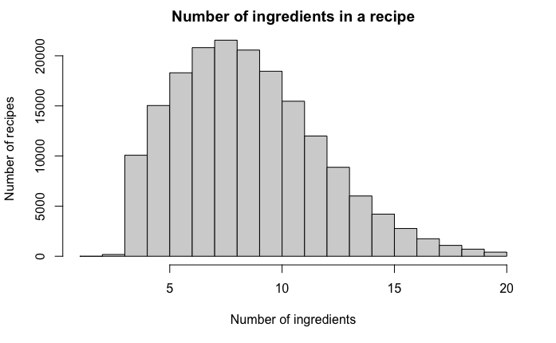

```r
hist(recipes$NumIngredients,
     breaks = 20,
     main = "Number of ingredients in a recipe",
     xlab = "Number of ingredients",
     ylab = "Number of recipes")
```

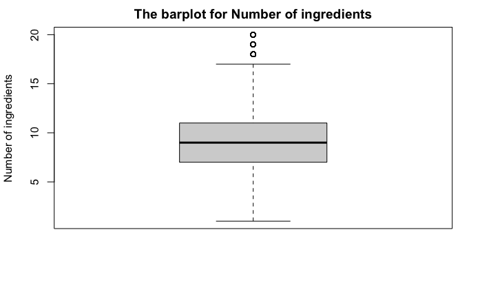

```r
boxplot(recipes$NumIngredients,
        ylab = "Number of ingredients",
        main = "The barplot for Number of ingredients")
```

From the two graphs above we see that most recipes have less than 15 ingredients and 20 ingredients is the max. Looking at the top 15 ingredients we see

```r
temp <- ingr[!duplicated(ingr$replaced),]
head(temp[order(-temp$count),], 15)
```

|  | X | raw_ingr | raw_words | processed | len_proc | replaced | count | id |
| --- | --- | --- | --- | --- | --- | --- | --- | --- |
| 903 | 902 | aunt jane's krazy mixed up salt | 6 | salt | 4 | salt | 72848 | 6270 |
| 6658 | 6657 | butter flavor crisco | 3 | butter | 6 | butter | 48039 | 840 |
| 10969 | 10968 | eggs | 1 | egg | 3 | egg | 43350 | 2499 |
| 10568 | 10567 | durkee onions | 2 | onion | 5 | onion | 42631 | 5010 |
| 11019 | 11018 | sugar | 1 | sugar | 5 | sugar | 37464 | 6906 |
| 541 | 540 | goat cheese packed in olive oil and basil | 8 | goat cheese packed in olive oil and basil | 41 | olive oil | 34402 | 5006 |
| 9090 | 9089 | garlic clove | 2 | garlic clove | 12 | garlic clove | 29815 | 3203 |
| 10947 | 10946 | water | 1 | water | 5 | water | 28592 | 7655 |
| 6066 | 6065 | 2% low-fat milk | 3 | milk | 4 | milk | 24114 | 4717 |
| 4753 | 4752 | bread machine flour | 3 | flmy | 4 | flmy | 23078 | 2683 |

[output cut: 5 more lines]

Investigating what ‘flmy’ is:

```r
head(ingr[ingr$replaced == "flmy", ])
```

|  | X | raw_ingr | raw_words | processed | len_proc | replaced | count | id |
| --- | --- | --- | --- | --- | --- | --- | --- | --- |
| 4753 | 4752 | bread machine flour | 3 | flmy | 4 | flmy | 23078 | 2683 |
| 4754 | 4753 | gluten-free flour | 2 | flmy | 4 | flmy | 23078 | 2683 |
| 4755 | 4754 | flour | 1 | flmy | 4 | flmy | 23078 | 2683 |

Clearly, this stands for flour.

Of the top 15 ingredients, salt and water can be assumed. Also, garlic clove and garlic can be combined into 1. Removing these ingredients from the top 15, we get

```r
# Adjusting the list further, I decided to combine all-purpose flower with flower,
# baking powder and baking soda
commonIngredients <- c('salt', 'water', 'garlic clove',
                       'salt and pepper', 'all-purpose flmy',
                       'baking soda', 'vanilla')
temp <- ingr[!duplicated(ingr$replaced),]
temp <- temp[!(temp$replaced %in% commonIngredients), ]
head(temp[order(-temp$count),], 20)
```

|  | X | raw_ingr | raw_words | processed | len_proc | replaced | count | id |
| --- | --- | --- | --- | --- | --- | --- | --- | --- |
| 6658 | 6657 | butter flavor crisco | 3 | butter | 6 | butter | 48039 | 840 |
| 10969 | 10968 | eggs | 1 | egg | 3 | egg | 43350 | 2499 |
| 10568 | 10567 | durkee onions | 2 | onion | 5 | onion | 42631 | 5010 |
| 11019 | 11018 | sugar | 1 | sugar | 5 | sugar | 37464 | 6906 |
| 541 | 540 | goat cheese packed in olive oil and basil | 8 | goat cheese packed in olive oil and basil | 41 | olive oil | 34402 | 5006 |
| 6066 | 6065 | 2% low-fat milk | 3 | milk | 4 | milk | 24114 | 4717 |
| 4753 | 4752 | bread machine flour | 3 | flmy | 4 | flmy | 23078 | 2683 |
| 11017 | 11016 | pepper | 1 | pepper | 6 | pepper | 20027 | 5319 |
| 9153 | 9152 | brown sugar | 2 | brown sugar | 11 | brown sugar | 16611 | 800 |
| 10985 | 10984 | garlic | 1 | garlic | 6 | garlic | 15393 | 3184 |

[output cut: 10 more lines]

Based on this, I will select the top 20 ingredients that are not in the commonIngredients list.